# STATS 326/786

Week 4 Tutorial

# Problem 1

> Below is some fake seasonal data (with a perfectly periodic pattern) with no trend and no remainder components. In class, we learned that moving averages are useful for smoothing time series. Compute a $2 \times 4~\text{MA}$ and a $5~\text{MA}$ and overlay these on the original time series. What do you notice, and why is this happening?

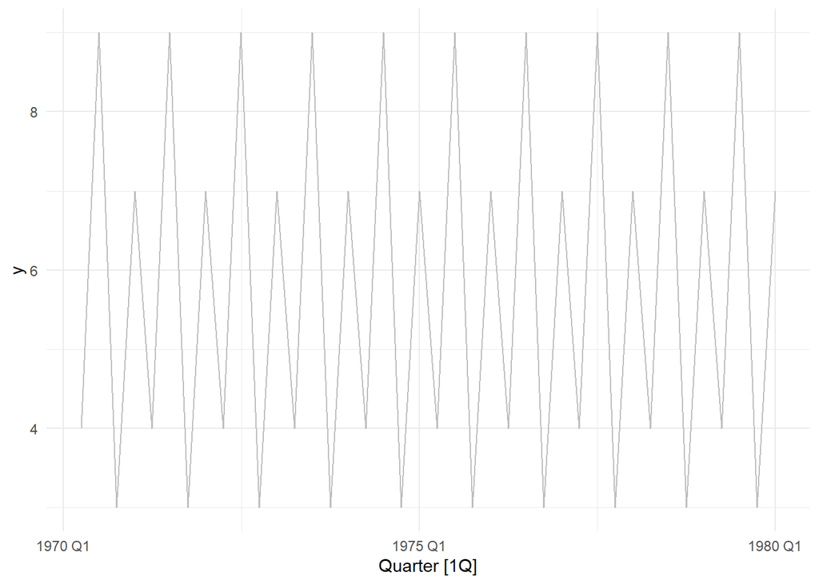

```r
data <- tsibble(Quarter = yearquarter(1:40),
                y = rep(c(4, 9, 3, 7), 10),
                index = Quarter)

data %>%
  autoplot(y, colour = "grey") +
  theme_minimal()
```

> Repeat the above exercise, but for the fake data below. This data is seasonal (again, with a perfectly periodic pattern) with a linear trend and no remainder component.

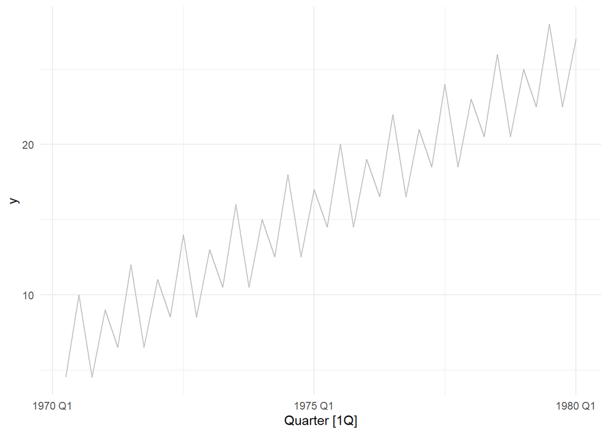

```r
data <- tsibble(Quarter = yearquarter(1:40),
                y = rep(c(4, 9, 3, 7), 10) + 0.5 * 1:40,
                index = Quarter)

data %>%
  autoplot(y, colour = "grey") +
  theme_minimal()
```

> If you were to apply a $3 \times 5~\text{MA}$ to a time series, analytically derive the weights that each observation contributes to the moving-averaged time series at time $t$.

# Problem 2

> Below is an example of a time series with multiplicative seasonality. In this problem, you learn how to perform your own (multiplicative) classical decomposition from first principles.

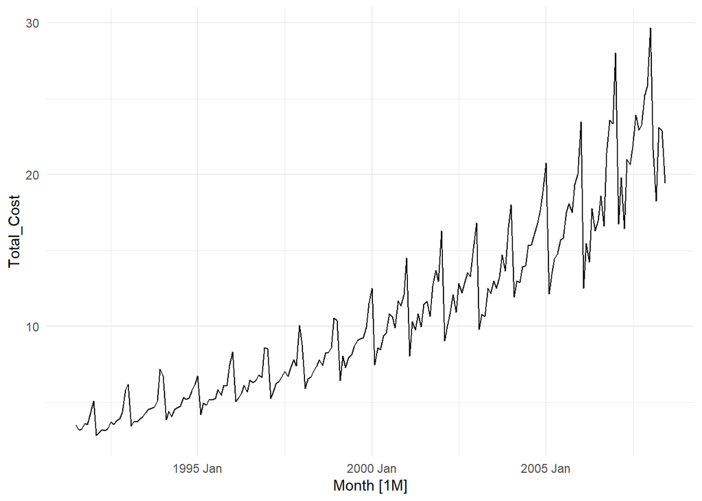

```r
a10 <- PBS %>%
  filter(ATC2 == "A10") %>%
  select(Month, Concession, Type, Cost) %>%
  summarise(Total_Cost = sum(Cost)) %>%
  mutate(Total_Cost = Total_Cost / 1e6,
         Month.Name = month(Month, label = TRUE))

a10 %>%
  autoplot(Total_Cost) +
  theme_minimal()
```

> Calculate the trend-cycle by performing a $2\times 12~\text{MA}$ on your time series.

> Compute the detrended time series (original time series divided by trend).

> Calculate the seasonal factor for each month (noting that these must sum to 12 for a monthly time series).

> Merge your data sets so the seasonal factor is now included in your original `tsibble`.

> Compute the remainder component (as detrended divided by seasonal) and seasonally-adjusted component (as original time series divided by seasonal).

> Plot the original time series and overlay it with the trend-cycle and seasonally-adjusted series.

> Extra: See if you can re-create the classical decomposition plot.